# Prediction Assignment Writeup

Aleksander Omelyanyuk

October 18, 2018

One thing that people regularly do is quantify how much of a particular activity they do, but they rarely quantify how well they do it. In this project, my goal will be to use data from accelerometers on the belt, forearm, arm, and dumbell of 6 participants.

## What I should submit

The goal of your project is to predict the manner in which they did the exercise. This is the “classe” variable in the training set. You may use any of the other variables to predict with. You should create a report describing how you built your model, how you used cross validation, what you think the expected out of sample error is, and why you made the choices you did. You will also use your prediction model to predict 20 different test cases.

## Recieving data

All data in two tables pml-training.csv and pml-testing.csv. I will use pml-training data for model creating and testing. In code below I loading needable libraries and data.

```r
#### Libraries
library(caret)
```

```r
library(rpart)
library(rpart.plot)
library(randomForest)
### Data loading
urlTrain<-"https://d396qusza40orc.cloudfront.net/predmachlearn/pml-training.csv"
url_final_test<-"https://d396qusza40orc.cloudfront.net/predmachlearn/pml-testing.csv"
my_data<-read.csv(urlTrain,na.strings = c("NA","#DIV/0!",""))
final_test<-read.csv(url_final_test,na.strings = c("NA","#DIV/0!",""))

###loaded data
str(my_data)
```

```
## 'data.frame':    19622 obs. of  160 variables:
##  $ X                       : int  1 2 3 4 5 6 7 8 9 10 ...
##  $ user_name               : Factor w/ 6 levels "adelmo","carlitos",..: 2 2 2 2 2 2 2 2 2 2 ...
##  $ raw_timestamp_part_1    : int  1323084231 1323084231 1323084231 1323084232 1323084232 1323084232 1323084232 1323084232 1323084232 1323084232 ...
##  $ raw_timestamp_part_2    : int  788290 808298 820366 120339 196328 304277 368296 440390 484323 484434 ...
##  $ cvtd_timestamp          : Factor w/ 20 levels "02/12/2011 13:32",..: 9 9 9 9 9 9 9 9 9 9 ...
##  $ new_window              : Factor w/ 2 levels "no","yes": 1 1 1 1 1 1 1 1 1 1 ...
##  $ num_window              : int  11 11 11 12 12 12 12 12 12 12 ...
##  $ roll_belt               : num  1.41 1.41 1.42 1.48 1.48 1.45 1.42 1.42 1.43 1.45 ...
##  $ pitch_belt              : num  8.07 8.07 8.07 8.05 8.07 8.06 8.09 8.13 8.16 8.17 ...
##  $ yaw_belt                : num  -94.4 -94.4 -94.4 -94.4 -94.4 -94.4 -94.4 -94.4 -94.4 -94.4 ...
##  $ total_accel_belt        : int  3 3 3 3 3 3 3 3 3 3 ...
##  $ kurtosis_roll_belt      : num  NA NA NA NA NA NA NA NA NA NA ...
##  $ kurtosis_picth_belt     : num  NA NA NA NA NA NA NA NA NA NA ...
##  $ kurtosis_yaw_belt       : logi  NA NA NA NA NA NA ...
```

[output cut: 86 more lines]

## Preprocessing the Data

As wee can see, in tables with data many fields with “NA” variables. I must clean data for analysis. In code below I well do it. Some variables have no sense, like “X”, “raw_timestamp_part_1”, “raw_timestamp_part_2”, “cvtd_timestamp”, I remove this variables too. For training and testing I will use 75 and 25 percents of data “pml-training.csv”.

```r
cut_off <- apply(my_data, 2, function(x) sum(is.na(x)))/nrow(my_data)

my_data <- my_data[!(cut_off > .95)]
final_test<-final_test[!(cut_off > .95)]

cut_off<-nearZeroVar(my_data)

my_data<-my_data[,-cut_off]
final_test<-final_test[,-cut_off]

my_data<-my_data[,-c(1,3,4,5)]
final_test<-final_test[,-c(1,3,4,5)]

str(my_data)
```

```
## 'data.frame':    19622 obs. of  55 variables:
##  $ user_name           : Factor w/ 6 levels "adelmo","carlitos",..: 2 2 2 2 2 2 2 2 2 2 ...
##  $ num_window          : int  11 11 11 12 12 12 12 12 12 12 ...
##  $ roll_belt           : num  1.41 1.41 1.42 1.48 1.48 1.45 1.42 1.42 1.43 1.45 ...
##  $ pitch_belt          : num  8.07 8.07 8.07 8.05 8.07 8.06 8.09 8.13 8.16 8.17 ...
##  $ yaw_belt            : num  -94.4 -94.4 -94.4 -94.4 -94.4 -94.4 -94.4 -94.4 -94.4 -94.4 ...
##  $ total_accel_belt    : int  3 3 3 3 3 3 3 3 3 3 ...
##  $ gyros_belt_x        : num  0 0.02 0 0.02 0.02 0.02 0.02 0.02 0.02 0.03 ...
##  $ gyros_belt_y        : num  0 0 0 0 0.02 0 0 0 0 0 ...
##  $ gyros_belt_z        : num  -0.02 -0.02 -0.02 -0.03 -0.02 -0.02 -0.02 -0.02 -0.02 0 ...
##  $ accel_belt_x        : int  -21 -22 -20 -22 -21 -21 -22 -22 -20 -21 ...
##  $ accel_belt_y        : int  4 4 5 3 2 4 3 4 2 4 ...
##  $ accel_belt_z        : int  22 22 23 21 24 21 21 21 24 22 ...
##  $ magnet_belt_x       : int  -3 -7 -2 -6 -6 0 -4 -2 1 -3 ...
##  $ magnet_belt_y       : int  599 608 600 604 600 603 599 603 602 609 ...
```

[output cut: 41 more lines]

```r
my_train<-createDataPartition(my_data$classe,p=.75,list = FALSE)

train_data<-my_data[my_train,]
test_data<-my_data[-my_train,]
```

## Processing the Data

### Rpart model

```r
set.seed(1)
fit_rpart<-rpart(data = train_data,classe ~ ., method = "class")
pred_rpart<-predict(fit_rpart,test_data,type = "class")

rpart_prediction<-confusionMatrix(pred_rpart,test_data$classe)
print(rpart_prediction)
```

```
## Confusion Matrix and Statistics
##
##           Reference
## Prediction    A    B    C    D    E
##          A 1239  200   38   70   45
##          B   57  534   28   34   27
##          C    4   60  697  115   53
##          D   78  103   45  519  111
##          E   17   52   47   66  665
##
## Overall Statistics
##
##                Accuracy : 0.7451
##                  95% CI : (0.7327, 0.7573)
##     No Information Rate : 0.2845
##     P-Value [Acc > NIR] : < 2.2e-16
##
##                   Kappa : 0.6763
##  Mcnemar's Test P-Value : < 2.2e-16
##
## Statistics by Class:
##
##                      Class: A Class: B Class: C Class: D Class: E
## Sensitivity            0.8882   0.5627   0.8152   0.6455   0.7381
## Specificity            0.8994   0.9631   0.9427   0.9178   0.9545
## Pos Pred Value         0.7783   0.7853   0.7503   0.6063   0.7851
## Neg Pred Value         0.9529   0.9018   0.9603   0.9296   0.9418
## Prevalence             0.2845   0.1935   0.1743   0.1639   0.1837
## Detection Rate         0.2527   0.1089   0.1421   0.1058   0.1356
## Detection Prevalence   0.3246   0.1387   0.1894   0.1746   0.1727
## Balanced Accuracy      0.8938   0.7629   0.8790   0.7817   0.8463
```

```r
varImp(fit_rpart)
```

```
##                         Overall
## accel_arm_x           430.43060
## accel_belt_x          246.16556
## accel_belt_y          143.09662
## accel_belt_z          669.78225
## accel_dumbbell_x       96.94181
## accel_dumbbell_y     1249.20480
## accel_dumbbell_z      256.37332
## accel_forearm_x       411.72789
## accel_forearm_z       233.54297
## gyros_dumbbell_x       70.00501
## magnet_arm_x          441.06905
## magnet_belt_y         795.11226
## magnet_belt_z         564.80686
## magnet_dumbbell_x     594.14870
## magnet_dumbbell_y    1482.79423
## magnet_dumbbell_z    1825.27311
## magnet_forearm_y      254.47989
## magnet_forearm_z      454.61866
## num_window           2367.87615
## pitch_belt           1391.15620
## pitch_dumbbell        220.35673
## pitch_forearm        1825.46329
## roll_arm               96.66772
## roll_belt            1461.49070
## roll_dumbbell         691.34487
## roll_forearm         1992.88076
## total_accel_belt      553.95999
## total_accel_dumbbell  319.76507
## user_name             416.78532
## yaw_belt             1528.75746
## yaw_dumbbell          254.06876
## gyros_belt_x            0.00000
## gyros_belt_y            0.00000
## gyros_belt_z            0.00000
## magnet_belt_x           0.00000
## pitch_arm               0.00000
## yaw_arm                 0.00000
## total_accel_arm         0.00000
## gyros_arm_x             0.00000
## gyros_arm_y             0.00000
## gyros_arm_z             0.00000
## accel_arm_y             0.00000
## accel_arm_z             0.00000
## magnet_arm_y            0.00000
## magnet_arm_z            0.00000
## gyros_dumbbell_y        0.00000
## gyros_dumbbell_z        0.00000
## yaw_forearm             0.00000
## total_accel_forearm     0.00000
## gyros_forearm_x         0.00000
## gyros_forearm_y         0.00000
## gyros_forearm_z         0.00000
## accel_forearm_y         0.00000
## magnet_forearm_x        0.00000
```

We can see not all variables take part in model.

### Random Forest model

```r
set.seed(1)
fit_rf<-randomForest(data = train_data, classe ~ ., method = "class")
pred_rf<-predict(fit_rf,test_data, type = "class")
rf_prediction<-confusionMatrix(pred_rf,test_data$classe)
print(rf_prediction)
```

```
## Confusion Matrix and Statistics
##
##           Reference
## Prediction    A    B    C    D    E
##          A 1395    3    0    0    0
##          B    0  946    7    0    0
##          C    0    0  848    2    0
##          D    0    0    0  802    2
##          E    0    0    0    0  899
##
## Overall Statistics
##
##                Accuracy : 0.9971
##                  95% CI : (0.9952, 0.9984)
##     No Information Rate : 0.2845
##     P-Value [Acc > NIR] : < 2.2e-16
##
##                   Kappa : 0.9964
##  Mcnemar's Test P-Value : NA
##
## Statistics by Class:
##
##                      Class: A Class: B Class: C Class: D Class: E
## Sensitivity            1.0000   0.9968   0.9918   0.9975   0.9978
## Specificity            0.9991   0.9982   0.9995   0.9995   1.0000
## Pos Pred Value         0.9979   0.9927   0.9976   0.9975   1.0000
## Neg Pred Value         1.0000   0.9992   0.9983   0.9995   0.9995
## Prevalence             0.2845   0.1935   0.1743   0.1639   0.1837
## Detection Rate         0.2845   0.1929   0.1729   0.1635   0.1833
## Detection Prevalence   0.2851   0.1943   0.1733   0.1639   0.1833
## Balanced Accuracy      0.9996   0.9975   0.9957   0.9985   0.9989
```

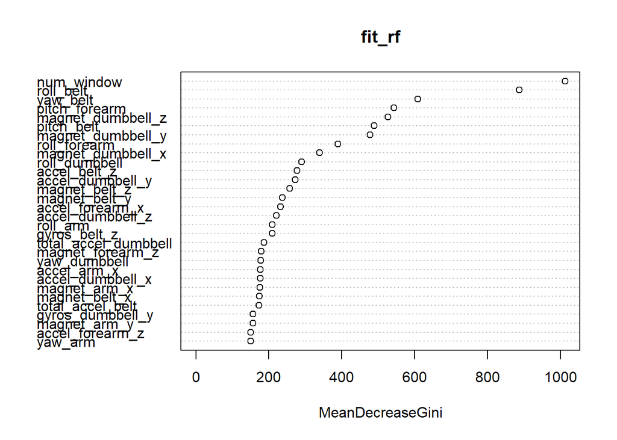

```r
varImpPlot(fit_rf)
```

This model more slower, but more accuracy, in my mind all variables taake part in model creation.

### Final result

For final result I use random forest model, because it more accuracy.

```r
final_predict<-predict(fit_rf,final_test, method = "class")
print(final_predict)
```

```
##  1  2  3  4  5  6  7  8  9 10 11 12 13 14 15 16 17 18 19 20
##  B  A  B  A  A  E  D  B  A  A  B  C  B  A  E  E  A  B  B  B
## Levels: A B C D E
```

## RESULT

In this work I use 2 models random forest and rpart. Rpart more faster but random forest have more accuracy.